# Data621-Week08-Discussion

Pavan Akula

March 23, 2018

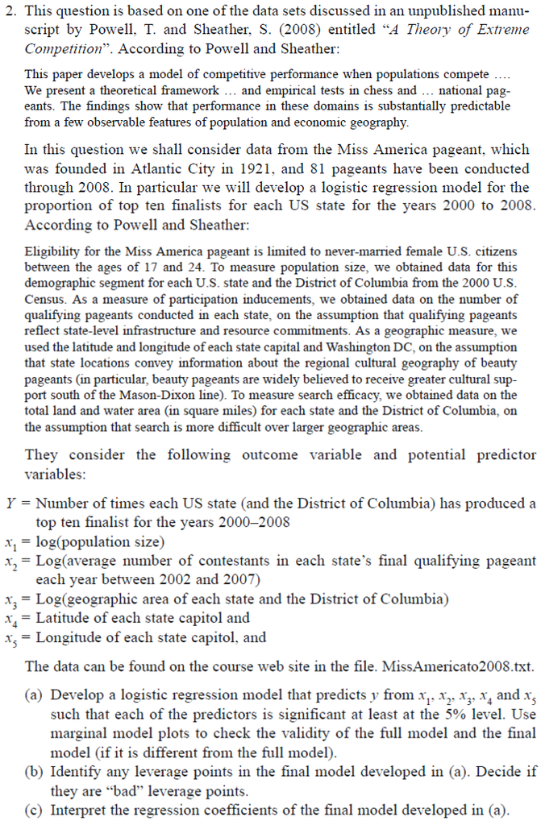

### *Answer (a):*

#### Data

The data file is loaded from http://www.stat.tamu.edu/~sheather/book/data_sets.php, file is `tab` separated, I converted into `comma` separated `csv` file.

```r
options(scipen=999)
library(dplyr)
library(tidyverse)
library(knitr)
library(kableExtra)
library(car)
library(ggrepel)
library(ggplot2)

#Load data

MissAm.df <- read.csv("https://raw.githubusercontent.com/akulapa/Data621-Week08-Discussion/master/MissAmericato2008.csv", header= TRUE, stringsAsFactors = F)
attach(MissAm.df)
```

Dataset structure, the variable `Top10` represents the number of times `state` made into top 10 list from `2000` to `2008`, including `2000` and `2008`. The number of times `state` did not make into `Top10` list is `9 - Top10`.

```r
str(MissAm.df)
```

```
## 'data.frame':    51 obs. of  7 variables:
##  $ abbreviation  : chr  "AL" "AK" "AZ" "AR" ...
##  $ Top10         : int  6 0 0 4 5 0 2 0 2 3 ...
##  $ LogPopulation : num  11.9 9.8 12.1 11.3 14 ...
##  $ LogContestants: num  3.9 2.71 2.86 3.77 3.94 ...
##  $ LogTotalArea  : num  10.9 13.4 11.6 10.9 12 ...
##  $ Latitude      : num  32.4 58.4 33.4 34.7 38.5 ...
##  $ Longitude     : num  86.4 134.6 112 92.2 121.5 ...
```

```r
summary(MissAm.df)
```

```
##  abbreviation           Top10       LogPopulation    LogContestants
##  Length:51          Min.   :0.000   Min.   : 9.693   Min.   :1.910
##  Class :character   1st Qu.:0.000   1st Qu.:10.843   1st Qu.:2.857
##  Mode  :character   Median :2.000   Median :11.757   Median :3.091
##                     Mean   :1.765   Mean   :11.682   Mean   :3.136
##                     3rd Qu.:3.000   3rd Qu.:12.354   3rd Qu.:3.450
##                     Max.   :7.000   Max.   :14.001   Max.   :4.040
##   LogTotalArea      Latitude       Longitude
##  Min.   : 4.22   Min.   :21.33   Min.   : 69.80
##  1st Qu.:10.49   1st Qu.:35.99   1st Qu.: 78.06
##  Median :10.94   Median :39.75   Median : 89.67
##  Mean   :10.62   Mean   :39.40   Mean   : 93.14
##  3rd Qu.:11.34   3rd Qu.:42.77   3rd Qu.:102.78
##  Max.   :13.40   Max.   :58.37   Max.   :157.92
```

```r
state.df <- data.frame(abbreviation = state.abb, State=state.name, stringsAsFactors = F)
MissAm.df <- MissAm.df %>%
  mutate(InTop10 = ifelse(Top10>0, 1, 0)) %>%
  inner_join(state.df)

MissAm.df %>%
  select(State, Top10, InTop10, LogPopulation, LogContestants, LogTotalArea, Latitude, Longitude) %>%
  kable("html",caption = "Miss America Contest - Number of Times State Produced Top 10 Finalist`(2000 - 2008)`") %>%
  kable_styling(bootstrap_options = c("striped", "hover", "condensed", "responsive"), full_width = T, position = "left", font_size = 12) %>%
  scroll_box(width = "100%", height = "250px")
```

Miss America Contest - Number of Times State Produced Top 10 Finalist`(2000 - 2008)`

| State | Top10 | InTop10 | LogPopulation | LogContestants | LogTotalArea | Latitude | Longitude |
| --- | --- | --- | --- | --- | --- | --- | --- |
| Alabama | 6 | 1 | 11.9249 | 3.895894 | 10.8670 | 32.3833 | 86.367 |
| Alaska | 0 | 0 | 9.8011 | 2.708050 | 13.4049 | 58.3667 | 134.583 |
| Arizona | 0 | 0 | 12.0543 | 2.862201 | 11.6439 | 33.4333 | 112.017 |
| Arkansas | 4 | 1 | 11.2702 | 3.766997 | 10.8814 | 34.7333 | 92.233 |
| California | 5 | 1 | 14.0005 | 3.935739 | 12.0058 | 38.5167 | 121.500 |
| Colorado | 0 | 0 | 11.8820 | 2.944439 | 11.5530 | 39.7500 | 104.867 |
| Connecticut | 2 | 1 | 11.5742 | 2.944439 | 8.6203 | 41.7333 | 72.650 |
| Delaware | 0 | 0 | 10.3397 | 2.852631 | 7.8196 | 39.1333 | 75.467 |
| Florida | 3 | 1 | 13.0882 | 3.725693 | 11.0937 | 30.3833 | 84.367 |
| Georgia | 4 | 1 | 12.5558 | 3.875359 | 10.9925 | 33.6500 | 84.433 |
| Hawaii | 3 | 1 | 10.6205 | 2.564949 | 9.2994 | 21.3333 | 157.917 |
| Idaho | 0 | 0 | 10.6565 | 2.970414 | 11.3334 | 43.5667 | 116.217 |
| Illinois | 2 | 1 | 13.0341 | 3.238678 | 10.9667 | 39.8333 | 89.667 |
| Indiana | 2 | 1 | 12.3026 | 3.126761 | 10.5028 | 39.7333 | 86.283 |
| Iowa | 1 | 1 | 11.6306 | 2.879199 | 10.9380 | 41.5333 | 93.650 |
| Kansas | 1 | 1 | 11.4371 | 2.978925 | 11.3178 | 39.0667 | 95.633 |
| Kentucky | 2 | 1 | 11.7568 | 3.433987 | 10.6068 | 38.2000 | 84.867 |
| Louisiana | 2 | 1 | 12.1042 | 3.465736 | 10.8559 | 30.5333 | 91.150 |
| Maine | 0 | 0 | 10.6066 | 2.484907 | 10.4740 | 44.3167 | 69.800 |
| Maryland | 3 | 1 | 12.1239 | 3.218876 | 9.4260 | 39.0000 | 76.083 |
| Massachusetts | 2 | 1 | 12.4428 | 2.917771 | 9.2644 | 42.3667 | 71.033 |
| Michigan | 3 | 1 | 12.8257 | 3.367296 | 11.4795 | 42.7833 | 84.600 |
| Minnesota | 0 | 0 | 12.1286 | 2.724579 | 11.3730 | 44.8833 | 93.217 |
| Mississippi | 3 | 1 | 11.6233 | 3.703768 | 10.7879 | 32.3167 | 90.083 |
| Missouri | 0 | 0 | 12.1716 | 3.526361 | 11.1520 | 38.5667 | 92.183 |
| Montana | 0 | 0 | 10.2920 | 2.852631 | 11.8985 | 46.6000 | 112.000 |
| Nebraska | 0 | 0 | 11.0494 | 2.871680 | 11.2561 | 40.8500 | 96.750 |
| Nevada | 1 | 1 | 10.9462 | 2.549445 | 11.6133 | 39.1667 | 119.767 |
| New Hampshire | 1 | 1 | 10.6631 | 2.785011 | 9.1431 | 43.2000 | 71.500 |
| New Jersey | 2 | 1 | 12.5266 | 3.242592 | 9.0735 | 40.2167 | 74.767 |
| New Mexico | 0 | 0 | 11.0420 | 3.091042 | 11.7084 | 35.6167 | 106.083 |
| New York | 3 | 1 | 13.4873 | 3.072693 | 10.9070 | 42.7500 | 73.800 |
| North Carolina | 2 | 1 | 12.5005 | 3.332205 | 10.8934 | 35.8667 | 78.783 |
| North Dakota | 0 | 0 | 10.1843 | 3.032546 | 11.1662 | 46.7667 | 100.750 |
| Ohio | 0 | 0 | 12.9287 | 3.212187 | 10.7105 | 40.0000 | 82.883 |
| Oklahoma | 5 | 1 | 11.6138 | 3.784190 | 11.1548 | 35.4000 | 97.600 |
| Oregon | 1 | 1 | 11.6680 | 3.100092 | 11.4966 | 44.9167 | 123.017 |
| Pennsylvania | 4 | 1 | 13.0212 | 3.178054 | 10.7376 | 40.2000 | 76.767 |
| Rhode Island | 1 | 1 | 10.7402 | 2.656757 | 7.3428 | 41.7333 | 71.433 |
| South Carolina | 1 | 1 | 11.8946 | 3.725693 | 10.3741 | 33.9500 | 81.117 |
| South Dakota | 0 | 0 | 10.2306 | 2.674149 | 11.2531 | 44.3833 | 100.283 |
| Tennessee | 1 | 1 | 12.1059 | 3.564827 | 10.6488 | 36.1167 | 86.683 |
| Texas | 7 | 1 | 13.4640 | 3.811097 | 12.5009 | 30.3000 | 97.700 |
| Utah | 2 | 1 | 11.5123 | 4.040123 | 11.3492 | 40.7667 | 111.967 |
| Vermont | 0 | 0 | 10.0402 | 2.335375 | 9.1710 | 44.2667 | 72.567 |
| Virginia | 3 | 1 | 12.4058 | 3.258097 | 10.6637 | 37.5000 | 77.333 |
| Washington | 1 | 1 | 12.2114 | 2.995732 | 11.1747 | 46.9667 | 122.900 |
| West Virginia | 2 | 1 | 10.9746 | 3.091042 | 10.0953 | 38.3667 | 81.600 |
| Wisconsin | 3 | 1 | 12.2358 | 3.212187 | 11.0898 | 43.1333 | 89.333 |
| Wyoming | 0 | 0 | 9.6926 | 1.909542 | 11.4908 | 41.1500 | 104.817 |

#### Model

Coefficients of the full `Generalized Logistic Regression Model`.

```r
#Build model

MissAm.glm <- glm(InTop10 ~ LogPopulation + LogContestants + LogTotalArea + Latitude + Longitude, family=binomial(link = "logit"), data = MissAm.df)

MissAm.glm
```

```
##
## Call:  glm(formula = InTop10 ~ LogPopulation + LogContestants + LogTotalArea +
##     Latitude + Longitude, family = binomial(link = "logit"),
##     data = MissAm.df)
##
## Coefficients:
##    (Intercept)   LogPopulation  LogContestants    LogTotalArea
##      -11.68988         1.28041         2.81720        -1.30420
##       Latitude       Longitude
##       -0.01544         0.03781
##
## Degrees of Freedom: 49 Total (i.e. Null);  44 Residual
## Null Deviance:       62.69
## Residual Deviance: 35.97     AIC: 47.97
```

Summary of the model.

```r
summary(MissAm.glm)
```

```
##
## Call:
## glm(formula = InTop10 ~ LogPopulation + LogContestants + LogTotalArea +
##     Latitude + Longitude, family = binomial(link = "logit"),
##     data = MissAm.df)
##
## Deviance Residuals:
##     Min       1Q   Median       3Q      Max
## -2.2553  -0.3656   0.3466   0.5164   1.9389
##
## Coefficients:
##                 Estimate Std. Error z value Pr(>|z|)
## (Intercept)    -11.68988    9.58609  -1.219   0.2227
## LogPopulation    1.28041    0.64357   1.990   0.0466 *
## LogContestants   2.81720    1.65071   1.707   0.0879 .
## LogTotalArea    -1.30420    0.62712  -2.080   0.0376 *
## Latitude        -0.01544    0.10896  -0.142   0.8873
## Longitude        0.03781    0.03688   1.025   0.3052
## ---
## Signif. codes:  0 '***' 0.001 '**' 0.01 '*' 0.05 '.' 0.1 ' ' 1
##
## (Dispersion parameter for binomial family taken to be 1)
##
##     Null deviance: 62.687  on 49  degrees of freedom
## Residual deviance: 35.972  on 44  degrees of freedom
## AIC: 47.972
##
## Number of Fisher Scoring iterations: 5
```

```r
#Manually calculating Predicted and Fitted values
# man.pre<- MissAm.glm$coefficients[1] +
#   MissAm.glm$coefficients[2] * MissAm.df$LogPopulation +
#   MissAm.glm$coefficients[3] * MissAm.df$LogContestants +
#   MissAm.glm$coefficients[4] * MissAm.df$LogTotalArea +
#   MissAm.glm$coefficients[5] * MissAm.df$Latitude +
#   MissAm.glm$coefficients[6] * MissAm.df$Longitude
#
# man.fitted <- 1/(1 + (1/exp(man.pre)))

#Get coefficients
MissAm.Coe <- round(MissAm.glm$coefficients,4)
```

#### Summary Explanation

First part `Call`, shows information about `response variable` and `predictor variables`.

Logistic regression equation

$$ln \bigg(\frac{P}{1-P}\bigg) = \beta_0 + \beta_1{X_1} + \beta_2{X_2} + \beta_3{X_3} + \beta_4{X_4} + \beta_5{X_5}$$

$$ln \bigg(\frac{P}{1-P}\bigg) = -11.6899 + 1.2804LogPopulation + 2.8172LogContestants -1.3042LogTotalArea -0.0154Latitude + 0.0378Longitude$$

Probability is

$$P = \frac{e^{\beta_0 + \beta_1{X_1} + \beta_2{X_2} + \beta_3{X_3} + \beta_4{X_4} + \beta_5{X_5}}}{1 + {e^{\beta_0 + \beta_1{X_1} + \beta_2{X_2} + \beta_3{X_3} + \beta_4{X_4} + \beta_5{X_5}}}}$$

- For every unit increase of `LogPopulation`, $ln \bigg(\frac{p}{1-p}\bigg)$ increases by 1.2804. `LogPopulation` has a positive effect on the outcome when all other `predictor variables` are held constant. In other words, as log value of state population increases by one unit, `log odds` or `logits` for the state to make into `Top10` list of finalists increases by 1.2804.
- For every unit increase of `LogContestants`, $ln \bigg(\frac{p}{1-p}\bigg)$ increases by 2.8172. `LogContestants` has a positive effect on the outcome when all other `predictor variables` are held constant. As log value of contestants from a state increases by one unit, `log odds` or `logits` for the state to make into `Top10` list of finalists increases by 2.8172.
- For every unit increase of `LogTotalArea`, $ln \bigg(\frac{p}{1-p}\bigg)$ decreases by 1.3042. `LogTotalArea` has a negative effect on the outcome when all other `predictor variables` are held constant. As log value of the total area of a state increases by one unit, `log odds` or `logits` for the state to make into `Top10` list of finalists decreases by 1.3042.
- For every degree increase of `Latitude`, $ln \bigg(\frac{p}{1-p}\bigg)$ decreases by 0.0154. `Latitude` has a negative effect on the outcome when all other `predictor variables` are held constant. As log value of latitude of state capitol increases by one degree, `log odds` or `logits` for the state to make into `Top10` list of finalists decreases by 0.0154.
- For every degree increase of `Longitude`, $ln \bigg(\frac{p}{1-p}\bigg)$ increases by 0.0378. `Longitude` has a positive effect on the outcome when all other `predictor variables` are held constant. As log value of longitude of state capitol increases by one degree, `log odds` or `logits` for the state to make into `Top10` list of finalists increases by 0.0378.

Model also suggests,

- Variable `LogPopulation` and `LogTotalArea` are significent at 5% level
- Variables `LogContestants` is contributing to model and is significent at 10% level.
- Since p-value is high variables `Latitude` and `Longitude` are not significent to the model.

`Null deviance` is 62.687, and `Residual deviance` is 35.972, suggesting variables are needed to build the model. Lower the value of `deviance` better the model.

Akaike information criterion(`AIC`), gives the quality of the model. Lower the value of `AIC` better the model. Since this is full model, lets use `Step` function to see if `AIC` improves if we remove any variables from the model.

```r
step(MissAm.glm, test="LRT")
```

```
## Start:  AIC=47.97
## InTop10 ~ LogPopulation + LogContestants + LogTotalArea + Latitude +
##     Longitude
##
##                  Df Deviance    AIC    LRT Pr(>Chi)
## - Latitude        1   35.992 45.992 0.0202  0.88703
## - Longitude       1   37.292 47.292 1.3194  0.25071
## <none>                35.972 47.972
## - LogContestants  1   39.712 49.712 3.7397  0.05313 .
## - LogPopulation   1   40.709 50.709 4.7364  0.02953 *
## - LogTotalArea    1   42.067 52.067 6.0949  0.01356 *
## ---
## Signif. codes:  0 '***' 0.001 '**' 0.01 '*' 0.05 '.' 0.1 ' ' 1
##
## Step:  AIC=45.99
## InTop10 ~ LogPopulation + LogContestants + LogTotalArea + Longitude
##
##                  Df Deviance    AIC    LRT Pr(>Chi)
## - Longitude       1   37.981 45.981 1.9886 0.158485
## <none>                35.992 45.992
## - LogPopulation   1   40.992 48.992 4.9993 0.025358 *
## - LogContestants  1   41.302 49.302 5.3095 0.021209 *
## - LogTotalArea    1   44.344 52.344 8.3518 0.003853 **
## ---
## Signif. codes:  0 '***' 0.001 '**' 0.01 '*' 0.05 '.' 0.1 ' ' 1
##
## Step:  AIC=45.98
## InTop10 ~ LogPopulation + LogContestants + LogTotalArea
##
##                  Df Deviance    AIC    LRT Pr(>Chi)
## <none>                37.981 45.981
## - LogPopulation   1   41.708 47.708 3.7274  0.05353 .
## - LogContestants  1   42.521 48.521 4.5404  0.03310 *
## - LogTotalArea    1   44.446 50.446 6.4649  0.01100 *
## ---
## Signif. codes:  0 '***' 0.001 '**' 0.01 '*' 0.05 '.' 0.1 ' ' 1
```

```
##
## Call:  glm(formula = InTop10 ~ LogPopulation + LogContestants + LogTotalArea,
##     family = binomial(link = "logit"), data = MissAm.df)
##
## Coefficients:
##    (Intercept)   LogPopulation  LogContestants    LogTotalArea
##        -9.4502          1.0702          2.5447         -0.9303
##
## Degrees of Freedom: 49 Total (i.e. Null);  46 Residual
## Null Deviance:       62.69
## Residual Deviance: 37.98     AIC: 45.98
```

`AIC` value without `Latitude` and `Longitude` yield better value. The output of `step` suggests existence of `Latitude` and `Longitude` is not providing any value to the model. Let’s build a model without `Latitude` and `Longitude` variables.

```r
MissAm.glm_v1 <- glm(InTop10 ~ LogPopulation + LogContestants + LogTotalArea, family=binomial(link = "logit"), data = MissAm.df)

summary(MissAm.glm_v1)
```

```
##
## Call:
## glm(formula = InTop10 ~ LogPopulation + LogContestants + LogTotalArea,
##     family = binomial(link = "logit"), data = MissAm.df)
##
## Deviance Residuals:
##     Min       1Q   Median       3Q      Max
## -2.3100  -0.4617   0.3657   0.4814   2.0845
##
## Coefficients:
##                Estimate Std. Error z value Pr(>|z|)
## (Intercept)     -9.4502     6.1757  -1.530   0.1260
## LogPopulation    1.0702     0.6007   1.782   0.0748 .
## LogContestants   2.5447     1.3779   1.847   0.0648 .
## LogTotalArea    -0.9303     0.4293  -2.167   0.0302 *
## ---
## Signif. codes:  0 '***' 0.001 '**' 0.01 '*' 0.05 '.' 0.1 ' ' 1
##
## (Dispersion parameter for binomial family taken to be 1)
##
##     Null deviance: 62.687  on 49  degrees of freedom
## Residual deviance: 37.981  on 46  degrees of freedom
## AIC: 45.981
##
## Number of Fisher Scoring iterations: 5
```

#### Marginal Plots For Full Model

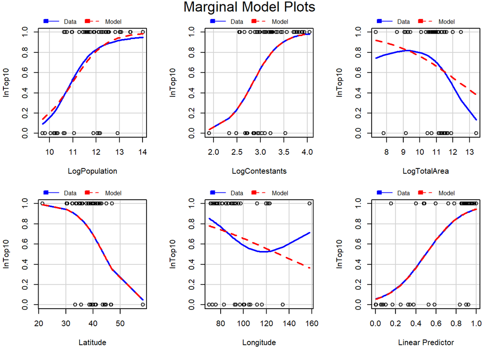

```r
mmps(MissAm.glm,layout=c(2,3),key=T)
```

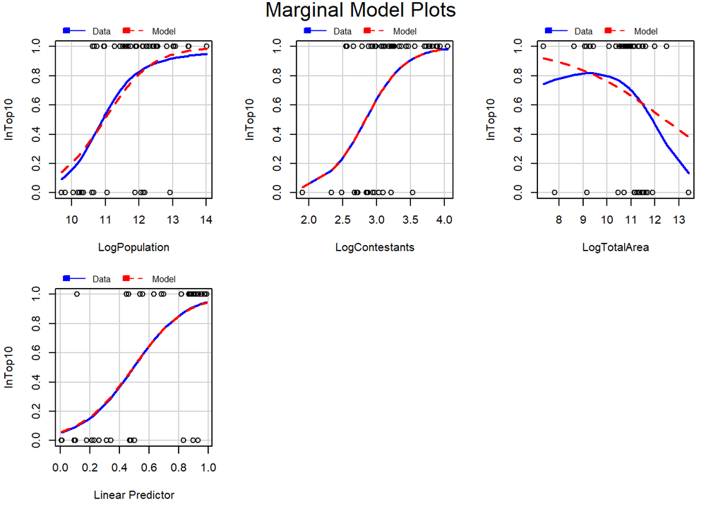

```r
mmps(MissAm.glm_v1,layout=c(2,3),key=T)
```

#### *Answer (b):*

The leverage $h_i$ is a measure of the distance between the $x$ value for the $i^{th}$ data point and the mean of the $x$ values for all $n$ data points. If leverage value greater than $2\times \frac{number\ of\ variables + 1}{number\ of\ observations}$ is considered as high leverage point. Leverage values are also known as `hat values`. We obtain the values using function `hatvalues`.

$$Standardized\ Deviance\ Residuals(r_i) = \frac{p_i}{\sqrt{(1 - h_i)}}$$

Leverage points can be identified using `influencePlot` function from `car` package or calculated manually.

```r
#Cut of leverage
#we have 4 variables and 50 observations
highLeverageHat = 2 * (3+1)/50

#Leverage values
MissAm.df$hatVal <- hatvalues(MissAm.glm_v1)

#standardized deviance residuals(sdr)
#Get pearson residuals
MissAm.df$pearsonResd <- residuals(MissAm.glm_v1,'pearson')

MissAm.df$sdr <- MissAm.df$pearsonResd / (sqrt(1 - MissAm.df$hatVal))

#Cook's distance
MissAm.df$cookd <- cooks.distance(MissAm.glm_v1)

#High leverage SDR
#data points falling outside 2 standard deviations
highLeverageSdrU <- mean(MissAm.df$sdr) + (2*sd(MissAm.df$sdr))
highLeverageSdrL <- mean(MissAm.df$sdr) - (2*sd(MissAm.df$sdr))

#High leverage based on Cook's distance
#data points falling outside 2 standard deviations
highLeverageCookdU <- mean(MissAm.df$cookd) + (2*sd(MissAm.df$cookd))
highLeverageCookdL <- mean(MissAm.df$cookd) - (2*sd(MissAm.df$cookd))

MissAm.df$Outlier <- ifelse((MissAm.df$hatVal > highLeverageHat | MissAm.df$sdr >  highLeverageSdrU | MissAm.df$sdr <  highLeverageSdrL | MissAm.df$cookd > highLeverageCookdU | MissAm.df$cookd < highLeverageCookdL),'Yes','No')
```

Identifying leverage data points Using `influencePlot` function

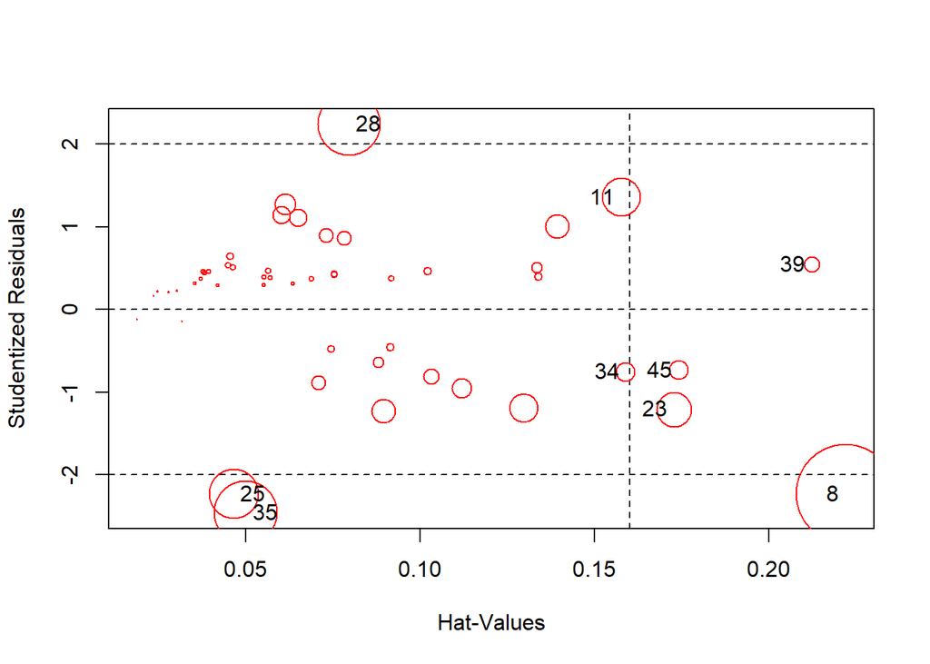

```
##       StudRes        Hat      CookD
## 8  -2.2315944 0.22191328 0.45381657
## 11  1.3549485 0.15762426 0.06839409
## 23 -1.2075931 0.17274282 0.05612712
## 25 -2.2347980 0.04654186 0.11263216
## 28  2.2400994 0.07957585 0.18272920
## 34 -0.7564691 0.15896707 0.01655727
## 35 -2.4581400 0.05002072 0.18585607
## 39  0.5455872 0.21222184 0.01187986
## 45 -0.7364479 0.17412150 0.01749629
```

```r
influencePlot(MissAm.glm_v1, col="red",id.n=5)
```

Manual calculation to identify leverage data points.

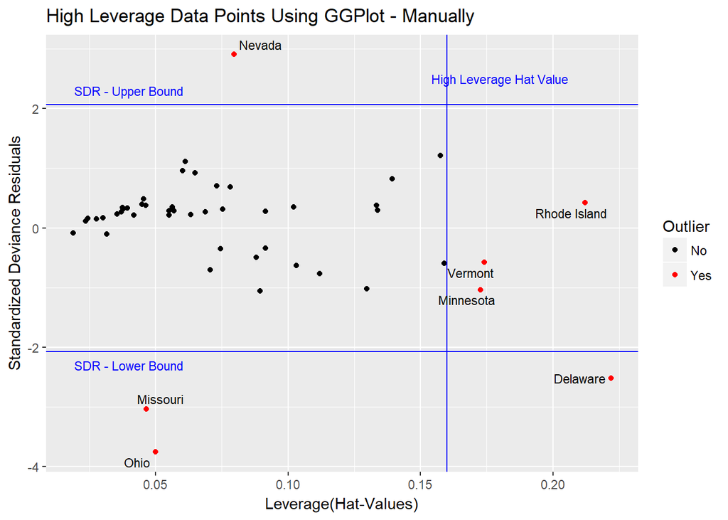

```r
ggplot(data=MissAm.df, aes(hatVal,sdr)) +
  geom_point(aes(col=Outlier)) +
  scale_color_manual(values=c("black", "red")) +
  geom_vline(xintercept=highLeverageHat, color="blue") +
  geom_hline(yintercept=c(highLeverageSdrU, highLeverageSdrL), color="blue") +
  geom_text_repel(data=filter(MissAm.df, (Outlier == 'Yes')), aes(hatVal,sdr, label=State), size=3) +
  labs(title = sprintf("High Leverage Data Points Using GGPlot - Manually")) + xlab("Leverage(Hat-Values)") +
  ylab("Standardized Deviance Residuals") +
  annotate("text", x = 0.04, y = -2.3, label = 'SDR - Lower Bound', colour="blue", size = 3) +
  annotate("text", x = 0.04, y = 2.3, label = 'SDR - Upper Bound', colour="blue", size = 3) +
  annotate("text", x = 0.18, y = 2.5, label = 'High Leverage Hat Value', colour="blue", size = 3)
```

```r
MissAm.df %>%
  select(State, Top10, InTop10, LogPopulation, LogContestants, LogTotalArea, Latitude, Longitude, pearsonResd, hatVal, sdr, cookd, Outlier) %>%
  filter(Outlier == 'Yes') %>%
  kable("html",caption = "Miss America Contest - High Leverage Data Points") %>%
  kable_styling(bootstrap_options = c("striped", "hover", "condensed", "responsive"), full_width = T, position = "left", font_size = 12) %>%
  scroll_box(width = "100%", height = "250px")
```

Miss America Contest - High Leverage Data Points

| State | Top10 | InTop10 | LogPopulation | LogContestants | LogTotalArea | Latitude | Longitude | pearsonResd | hatVal | sdr | cookd | Outlier |
| --- | --- | --- | --- | --- | --- | --- | --- | --- | --- | --- | --- | --- |
| Delaware | 0 | 0 | 10.3397 | 2.852631 | 7.8196 | 39.1333 | 75.467 | -2.2253921 | 0.2219133 | -2.5228564 | 0.4538166 | Yes |
| Minnesota | 0 | 0 | 12.1286 | 2.724579 | 11.3730 | 44.8833 | 93.217 | -0.9430982 | 0.1727428 | -1.0368994 | 0.0561271 | Yes |
| Missouri | 0 | 0 | 12.1716 | 3.526361 | 11.1520 | 38.5667 | 92.183 | -2.9664769 | 0.0465419 | -3.0380167 | 0.1126322 | Yes |
| Nevada | 1 | 1 | 10.9462 | 2.549445 | 11.6133 | 39.1667 | 119.767 | 2.7895320 | 0.0795758 | 2.9076180 | 0.1827292 | Yes |
| Ohio | 0 | 0 | 12.9287 | 3.212187 | 10.7105 | 40.0000 | 82.883 | -3.6623304 | 0.0500207 | -3.7575127 | 0.1858561 | Yes |
| Rhode Island | 1 | 1 | 10.7402 | 2.656757 | 7.3428 | 41.7333 | 71.433 | 0.3727730 | 0.2122218 | 0.4199934 | 0.0118799 | Yes |
| Vermont | 0 | 0 | 10.0402 | 2.335375 | 9.1710 | 44.2667 | 72.567 | -0.5235920 | 0.1741215 | -0.5761491 | 0.0174963 | Yes |

#### *Answer (c):*

```r
MissAm.glm <- glm(InTop10 ~ LogPopulation + LogContestants + LogTotalArea, family=binomial(link = "logit"), data = MissAm.df)
MissAm.Coe <- round(MissAm.glm$coefficients,4)
summary(MissAm.glm)
```

```
##
## Call:
## glm(formula = InTop10 ~ LogPopulation + LogContestants + LogTotalArea,
##     family = binomial(link = "logit"), data = MissAm.df)
##
## Deviance Residuals:
##     Min       1Q   Median       3Q      Max
## -2.3100  -0.4617   0.3657   0.4814   2.0845
##
## Coefficients:
##                Estimate Std. Error z value Pr(>|z|)
## (Intercept)     -9.4502     6.1757  -1.530   0.1260
## LogPopulation    1.0702     0.6007   1.782   0.0748 .
## LogContestants   2.5447     1.3779   1.847   0.0648 .
## LogTotalArea    -0.9303     0.4293  -2.167   0.0302 *
## ---
## Signif. codes:  0 '***' 0.001 '**' 0.01 '*' 0.05 '.' 0.1 ' ' 1
##
## (Dispersion parameter for binomial family taken to be 1)
##
##     Null deviance: 62.687  on 49  degrees of freedom
## Residual deviance: 37.981  on 46  degrees of freedom
## AIC: 45.981
##
## Number of Fisher Scoring iterations: 5
```

Model also suggests,

- Variable `LogTotalArea` is significent at 5% level
- Variables `LogContestants` and `LogPopulation` are contributing to model and are significent at 10% level.

`Null deviance` is 62.687, and `Residual deviance` is 37.981, suggesting variables are needed to build the model. Lower the value of `deviance` better the model.

#### References

- https://www.ncbi.nlm.nih.gov/pmc/articles/PMC4885900/
- https://www.youtube.com/watch?v=B2nJ3U4E1VA
- http://data.princeton.edu/wws509/notes/c3s8.html
- https://www.unc.edu/courses/2010fall/ecol/563/001/docs/lectures/lecture17.htm
- https://onlinecourses.science.psu.edu/stat501/node/338